# Graph Theory 1 Very Basics

ryamada

2020年5月21日

## What is a Graph? グラフって何？

A graph is a pair of a set of vertices and a set of edges, where edges that are pairs of vertices.

グラフは頂点の集合と辺の集合のペア。辺は頂点のペアである。

When the pairs of veritices of edges are unordered, the graph is an unordered graph and when the pairs are ordered, the graph is ordered.

辺をなす頂点ペアに順序がないとき、グラフは無向グラフと呼び、頂点ペアに順序があるとき、有向グラフと呼ぶ。

## Graphs represent various stuffs グラフによって表現されるいろいろなもの

- Road maps 道路地図
- Molecular structures 分子構造
- Electronic circuits 電子回路
- Algorithm アルゴリズム
- Relation among set and its subsets
- Factorization 因数分解

## Expression of graphs with computer languages グラフを計算機言語で表す

Assume a graph in the shape of square.

正方形の形をしたグラフを考える。

There are four vertices and four edges. 4個の頂点、4個の辺からなる。

There are two ways to express this square graph.

それを、次のように2通りの方法で表すことができる。

The first way is to make a list of edges with their vertices in a 2-column matrix 1つ目の方法は、エッジを構成する２頂点を並べるもの。2列の行列になる。

This is a matrix of edge list.

辺リスト行列。

$$\begin{pmatrix}
1,2\\
2,3\\
3,4\\
4,1
\end{pmatrix}$$

The other is to use a number-of-vertices x number of vertices square matrix. もう一つは、頂点数 x 頂点数の正方行列で表す方法。

When the i-th and j-th vertices are connected with an edge, the (i,j) and (j,i) cells of the matrix are 1 and otherwise 0.

i番頂点とj番頂点とが辺で結ばれているとき、行列の(i,j)と(j,i)のセルの値が1でそれ以外は0。

This is an adjacency matrix.

隣接行列。

$$\begin{pmatrix}
0,1,0,1\\
1,0,1,0\\
0,1,0,1\\
1,0,1,0
\end{pmatrix}$$

```r
library(igraph)
edge.list <- rbind(c(1,2),c(2,3),c(3,4),c(4,1))
edge.list
```

```
##      [,1] [,2]
## [1,]    1    2
## [2,]    2    3
## [3,]    3    4
## [4,]    4    1
```

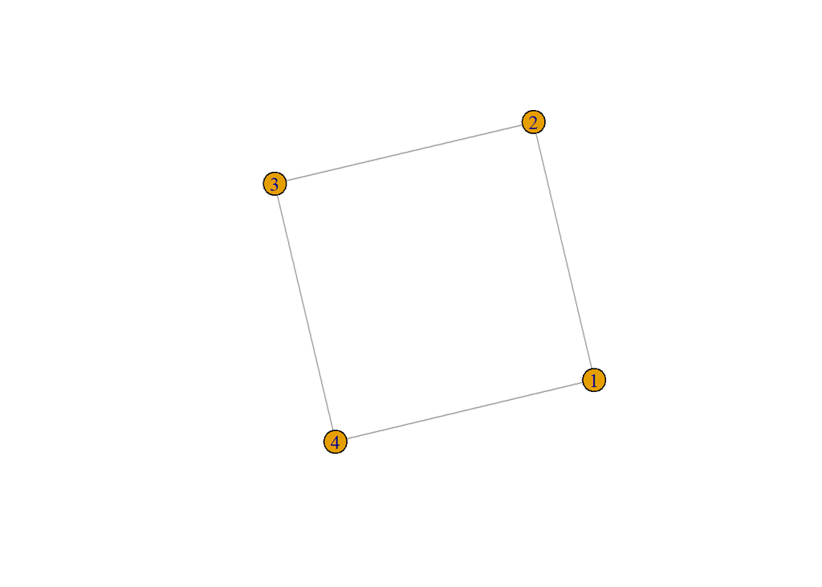

```r
g1 <- graph.edgelist(edge.list, directed = FALSE) # undirected graph
plot(g1)
```

```r
adj <- matrix(0,4,4) # 4: no. vertices
adj[1,2] <- adj[2,1] <- adj[2,3] <- adj[3,2] <- adj[3,4] <- adj[4,3] <- adj[4,1] <- adj[1,4] <- 1
adj
```

```
##      [,1] [,2] [,3] [,4]
## [1,]    0    1    0    1
## [2,]    1    0    1    0
## [3,]    0    1    0    1
## [4,]    1    0    1    0
```

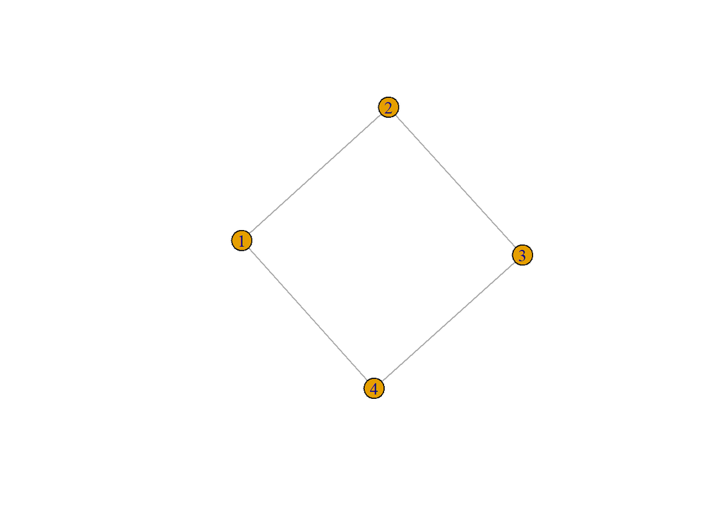

```r
g2 <- graph.adjacency(adj,mode="undirected")
plot(g2)
```

## “Usual”" Graphs and unusual graphs 「普通の」グラフとそうでないグラフ

Usual graphs have 0 or 1 edges between two different vertices.

普通のグラフは、異なる2頂点間に、辺がないか、あるとしても1本の辺しかないようなグラフ

### Adjacancy matrices of “usual” graphs 普通のグラフの隣接行列

The adjacency matrix of “square” graph is; 正方形グラフの隣接行列は

```r
adj
```

```
##      [,1] [,2] [,3] [,4]
## [1,]    0    1    0    1
## [2,]    1    0    1    0
## [3,]    0    1    0    1
## [4,]    1    0    1    0
```

The values of cells are 0 or 1. すべてのセルの値は0か1。 It is symmetric. 対称行列でもある。

### Unusual graphs 普通でないグラフ

If cells (1,2) and (2,1) are changed to 2; もし、(1,2)と(2,1)のセルを2に変えると;

```r
adj2 <- adj
adj2[1,2] <- adj2[2,1] <- 2
adj2
```

```
##      [,1] [,2] [,3] [,4]
## [1,]    0    2    0    1
## [2,]    2    0    1    0
## [3,]    0    1    0    1
## [4,]    1    0    1    0
```

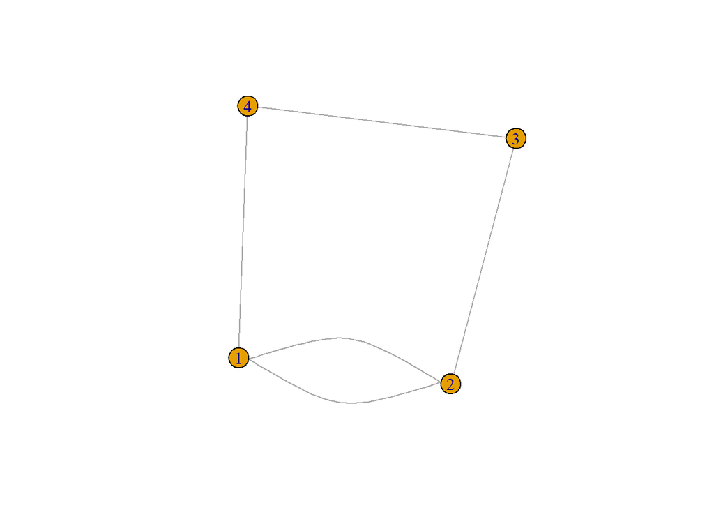

```r
g3 <- graph.adjacency(adj2,mode = "undirected")
plot(g3)
```

The number of edges between v1 and v2 is 2, meaning that it is an “unusual” graph.

頂点V1とV2とを結ぶエッジの本数が2となり、“普通ではない”グラフとなる

The diagonals of adjacency matrix of “usual” graphs are zero. 普通のグラフの隣接行列の対角成分は0。

Let’s change one of the diagonal cells from 0 to 1.

対角成分の1つの値を0から1に変えてみる。

```r
adj3 <- adj
adj3[2,2] <- 1
adj3
```

```
##      [,1] [,2] [,3] [,4]
## [1,]    0    1    0    1
## [2,]    1    1    1    0
## [3,]    0    1    0    1
## [4,]    1    0    1    0
```

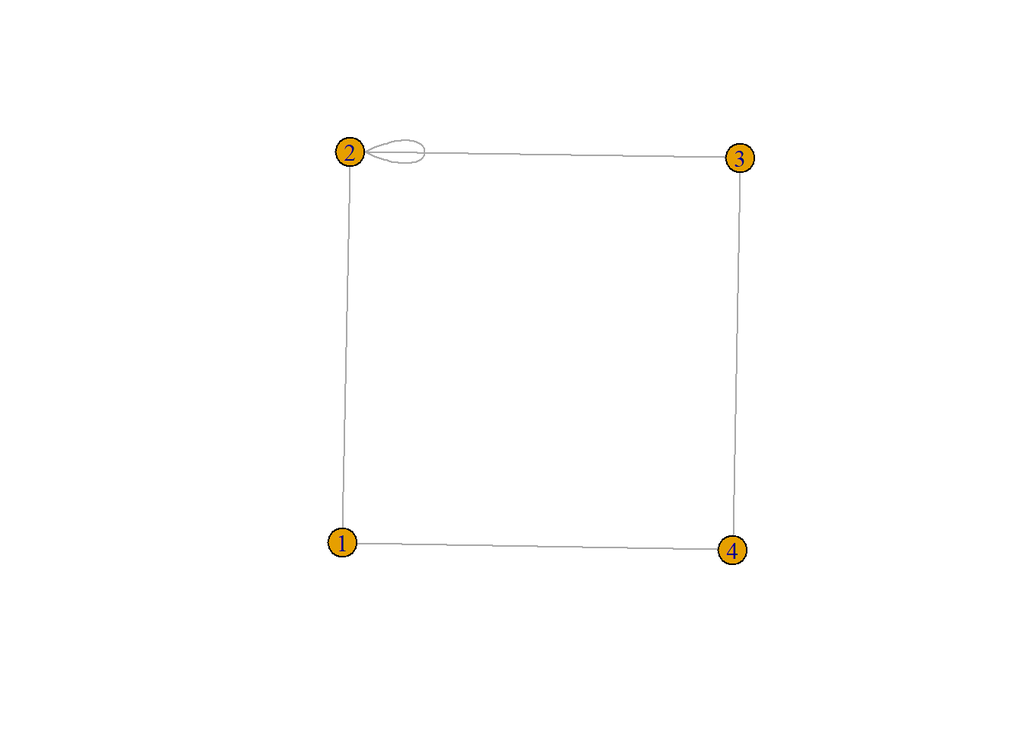

```r
g4 <- graph.adjacency(adj3,mode="undirected")
plot(g4)
```

The graph has an edge coming out from V2 and ending into V2.

V2から出てV2に終わる辺がある。

This is another “unusual” graph. これも「普通でない」グラフ。

The edge starting from and ending into the same vertex is called a “loop”.

同じ頂点から出て、同じ頂点に終わる辺を「ループ」と呼ぶ。

## Exercise 練習問題

- Make an edge list and an adjacency matrix of hexagon and draw the graph. 六角形のグラフのエッジリストと隣接行列を作り、そのグラフを描け
- Make an edge list and an adjacency matrix of a cubic and draw the graph. 立方体のグラフのエッジリストと隣接行列を作り、そのグラフを描け
- Make an edge list and an adjacency matrix of a Chinese character “寺” and draw the graph. 漢字「寺」のエッジリストと隣接行列を作り、そのグラフを描け